# Project - STAT 6313

- Show All Code
- Hide All Code
- View Source

Author

Baldwin, Jamie

# Libraries

**SHOW ME THE CODE!**

```r
library(tswge)
library(astsa)
library(seasonal)
library(ggplot2)
library(fpp3)        # For autoplot() and time series functions
library(scales)      # For dollar_format()
library(dplyr)       # For %>% pipe operator
library(gridExtra) # Required for arranging ggplots
library(tseries)
library(nnfor)
library(urca)
```

# Set Up

**SHOW ME THE CODE!**

```r
###### Finance Rate on Consumer Installment Loans at Commercial Banks, New Autos 60 Month Loan #####

#### Is actually quarter because of how FRED does the survey ####

auto <- read.csv("C:\\Users\\jasmi\\OneDrive - Southern Methodist University\\STAT 6313 Robertson\\Project\\RIFLPBCIANM60NM.csv")
```

# Cleaning & Viewing the Dataset

**SHOW ME THE CODE!**

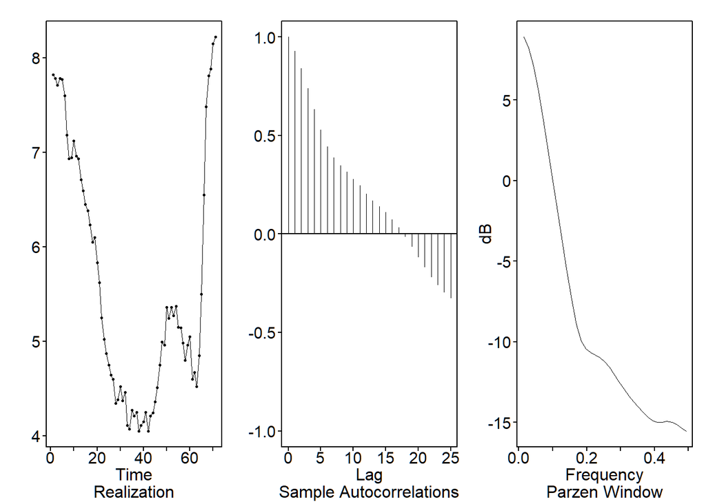

```r
## Dropping the NA months
clean_auto <- auto %>%
  drop_na(RIFLPBCIANM60NM) %>%
  arrange(observation_date) # Ensure they are in chronological order

## Verify we have 79 clean, consecutive points
# print(nrow(clean_auto))  #VERIFIED :)

## Extract just the rates

auto_rates <- clean_auto$RIFLPBCIANM60NM

n = length(auto_rates)
test_size = 8 ## Holding out the last 24 months (4 quarters * 2 years = 8) for the competition

## Create Train and Test sets
train = auto_rates[1:(n - test_size)]
test = auto_rates[(n - test_size + 1):n]

## Plot the Realization, Sample Autocorrelations, and Spectral Density of the Training Set
invisible(plotts.sample.wge(train))
```

From the realization, we can see that the data does NOT hover around a constant mean. Quickly violating the definition of stationarity, meaning we can conclude this dataset is NOT stationary. In addition to not being stationary, we can see that it drops smoothly from 8% down to right above 4%, and then it starts to climb but upwards. It “wanders” wherever the economy takes it.

Our Sample Autocorrelations plot, agree with our findings from the realization as it starts at 1.0 and decays incredibly slowly. It seems to take about 16 lags just to cross the zero line. This indicates non-stationarity as in a stationary series, it would drop to zero within the first two or three lags. In addition to non-stationarity, our ACF plot also shows no since of a cyclic pattern. If there were seasonal effects , we would see little bumps every 4 lags (since we have established this data is quarterly).

The Spectral Density plot shows a massive, dominant peak at $f=0$, and the then the variance drops exponentially as the frequency increases. A peak at $f=0$ is the mathematical signature of a trend or wandering behavior. While we can see a small bump at $f=0.23$, this is significantly weaker than the spike at $f=0$. This means there *might* be a small hint of a seasonal pattern, however due to how weak in comparison to the wandering behavior, I do not feel comfortable acting upon in as of right now. As this could also just be a hiccup from the Parzen Window Smoothing and not a real indicator of seasonality.

Overall, these finding make sense as interest rates are heavily managed by the Federal Reserve. Meaning they move in prolonged trends (hiking cycles/cutting cycles) rather than bouncing randomly around a fixed historical average. After we apply the first difference we will better be able to see if that hint of a annual cycle is real and then perhaps be able to build a model taking seasonality into account. If it is indeed just noise, the first difference will make it disappear.

# Testing for Unit Roots (ARIMA vs. ARMA)

Since our series shows since of wandering behavior, we will need to mathematically confirm if it contains a “unit root”. This will help us identify if we need to fit an ARIMA model (differenced) or an ARMA Model. To do so we will be using the Augmented Dickey-Fuller (ADF) and KPSS Tests.

**SHOW ME THE CODE!**

```r
cat("\n--- UNIT ROOT TESTS ---\n")
```

```
--- UNIT ROOT TESTS ---
```

**SHOW ME THE CODE!**

```r
###### Augmented Dickey-Fuller Test #####
## Null Hypothesis: The data has a unit root (is non-stationary)
## Alt Hypothesis: The data has NO unit root (is stationary)
adf_test = ur.df(train, type='drift', selectlags='AIC')
summary(adf_test)
```

```
###############################################
# Augmented Dickey-Fuller Test Unit Root Test #
###############################################

Test regression drift


Call:
lm(formula = z.diff ~ z.lag.1 + 1 + z.diff.lag)

Residuals:
     Min       1Q   Median       3Q      Max
-0.51672 -0.16460 -0.00722  0.13735  0.68490

Coefficients:
            Estimate Std. Error t value Pr(>|t|)
(Intercept)  0.15986    0.12296    1.30    0.198
z.lag.1     -0.02835    0.02180   -1.30    0.198
z.diff.lag   0.55559    0.10366    5.36 1.14e-06 ***
---
Signif. codes:  0 '***' 0.001 '**' 0.01 '*' 0.05 '.' 0.1 ' ' 1

Residual standard error: 0.2216 on 66 degrees of freedom
Multiple R-squared:  0.3054,    Adjusted R-squared:  0.2844
F-statistic: 14.51 on 2 and 66 DF,  p-value: 5.976e-06


Value of test-statistic is: -1.3001 0.8553

Critical values for test statistics:
      1pct  5pct 10pct
tau2 -3.51 -2.89 -2.58
phi1  6.70  4.71  3.86
```

**SHOW ME THE CODE!**

```r
##### KPSS Test #####
## Null Hypothesis: The data is stationary
## Alt Hypothesis: The data is NOT stationary
kpss_test = ur.kpss(train, type='mu', lags='short')
summary(kpss_test)
```

```
#######################
# KPSS Unit Root Test #
#######################

Test is of type: mu with 3 lags.

Value of test-statistic is: 0.5503

Critical value for a significance level of:
                10pct  5pct 2.5pct  1pct
critical values 0.347 0.463  0.574 0.739
```

Therefore, based on both of these tests we can conclude that the data is non-stationary (as our visual investigation indicated) and we should include a unit root in our model. Next, we will take the first difference and re-plot the data.

**SHOW ME THE CODE!**

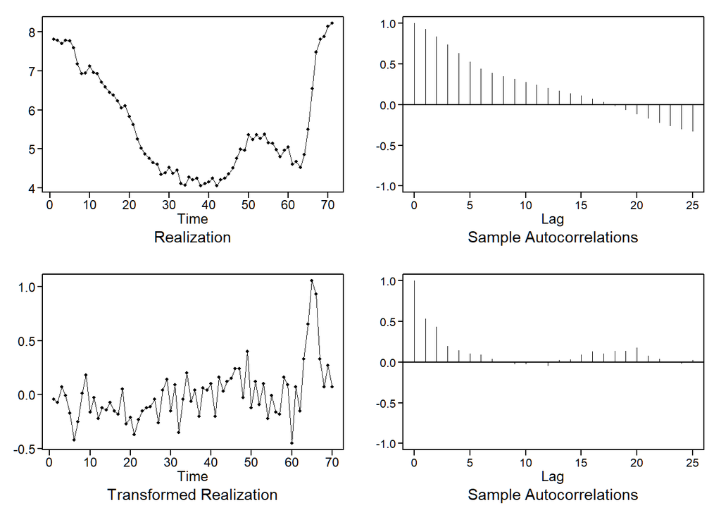

```r
###### Take the First Difference (Assuming tests confirm a unit root) #####
d1_train = artrans.wge(train, phi.tr=1)
```

**SHOW ME THE CODE!**

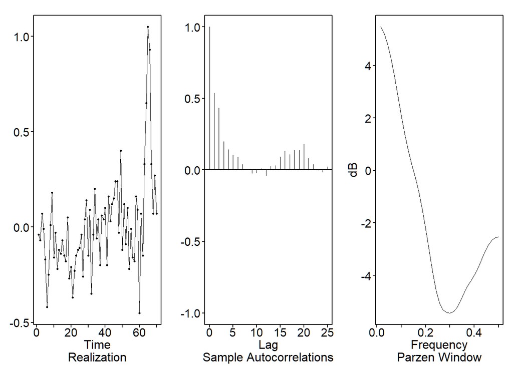

```r
## Plot the differenced data to see if the seasonal bump becomes clearer!
invisible(plotts.sample.wge(d1_train))
```

Now that our data is differenced we can move on to testing if there is a deterministic trend, using the Woodward-Bottone-Gray (WBG) Bootstrap Test.

# Testing for a Deterministic Trend

**SHOW ME THE CODE!**

```r
cat("\n--- WBG TREND TEST ---\n")
```

```
--- WBG TREND TEST ---
```

**SHOW ME THE CODE!**

```r
## Null hypothesis: There is NO deterministic linear trend (slope = 0)
## Alt Hypothesis: There IS a determininstic linear trend

wbg_test = wbg.boot.wge(train)
wbg_test$pv
```

```
[1] 0.566416
```

# Building our Models

**SHOW ME THE CODE!**

```r
cat("\n--- MODEL 1: ARIMA SELECTION ---\n")
```

```
--- MODEL 1: ARIMA SELECTION ---
```

**SHOW ME THE CODE!**

```r
## We'll use AIC to find the best p and q for the differenced data
#aic5.wge(d1_train, p=0:8, q=0:4)

## smallest p an q from above line plugged into here
p_val = 2
q_val = 0

## Estimate the final ARIMA parameters using chosen p and q
arima_fit = est.arma.wge(d1_train, p=p_val, q=q_val)
```

```
Coefficients of AR polynomial:
0.4186 0.2051

                           AR Factor Table
Factor                 Roots                Abs Recip    System Freq
1-0.7082B              1.4121               0.7082       0.0000
1+0.2896B             -3.4532               0.2896       0.5000
```

**SHOW ME THE CODE!**

```r
cat("\n---ARIMA RESIDUAL ANALYSIS---\n")
```

```
---ARIMA RESIDUAL ANALYSIS---
```

**SHOW ME THE CODE!**

```r
ljung.wge(arima_fit$res, p=2, q=0, K=24)
```

```
Obs 0.03466704 0.07584288 -0.1250056 -0.06160055 0.004009551 0.06691392 0.0179369 -0.007573899 -0.04799944 -0.0143805 0.02969527 -0.08699483 0.02484977 -0.03367524 0.03974375 0.09136073 -0.01455913 0.03247729 0.02881115 0.1599936 -0.00929813 -0.009767329 -0.05109633 -0.03003727
```

```
$test
[1] "Ljung-Box test"

$K
[1] 24

$chi.square
[1] 7.567185

$df
[1] 22

$pval
[1] 0.9981338
```

**SHOW ME THE CODE!**

```r
cat("\n--- MODEL 2: MULTILAYER PERCEPTRON (MLP) ---\n")
```

```
--- MODEL 2: MULTILAYER PERCEPTRON (MLP) ---
```

**SHOW ME THE CODE!**

```r
set.seed(1) ## set seed to ensure reproducability

## We set difforder=1 for the unit root, and allow.det.season=FALSE because we proved there is no seasonality
fit_mlp = mlp(ts(train, frequency = 4), difforder=1, allow.det.season=FALSE, reps=20)

# Display the architecture of the fitted neural network
print(fit_mlp)
```

```
MLP fit with 5 hidden nodes and 20 repetitions.
Series modelled in differences: D1.
Univariate lags: (1,2)
Forecast combined using the median operator.
MSE: 0.0281.
```

**SHOW ME THE CODE!**

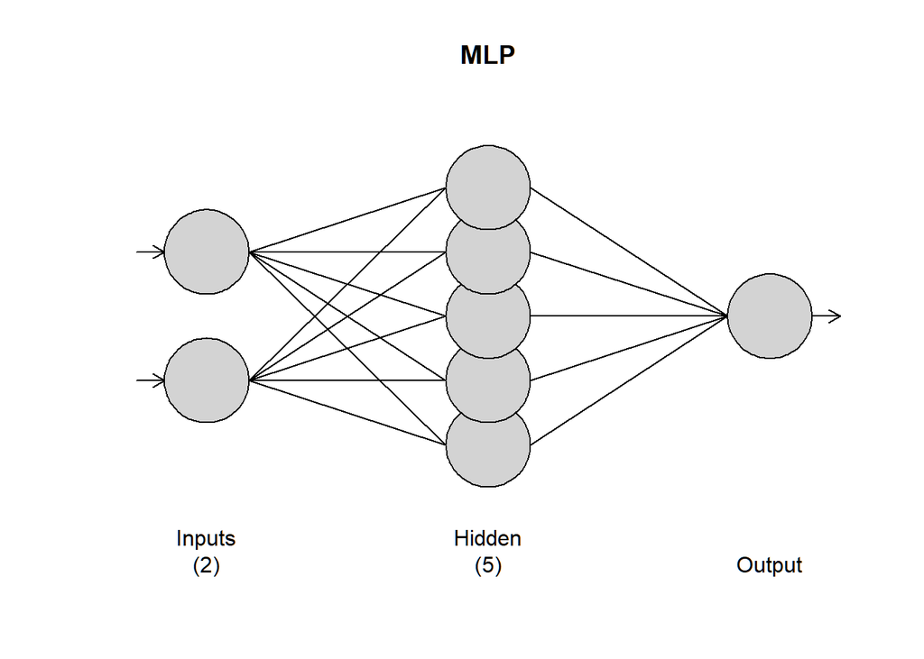

```r
plot(fit_mlp)
```

Our ARIMA Model is a ARIMA(2,1,0), meaning it is using the previous 2 quarters to predict the next one. The p-value from the Ljung-Box Test is 0.9981338 which is greater than 0.05 indicating that we fail to reject our null hypothesis. That is there is not evidence to support that our residuals are NOT white noise. Which is good, this is the result that we want!

# Evaluating our Models

**SHOW ME THE CODE!**

```r
cat("\n---EVALUATION (FORECASTING)---\n")
```

```
---EVALUATION (FORECASTING)---
```

**SHOW ME THE CODE!**

```r
## 1. ARIMA Forecast (h = 24 months)
## We specify d=1 because we differenced the data
fore_arima = fore.arima.wge(train, d=1, phi=arima_fit$phi, theta=0,
                            n.ahead=test_size, plot=FALSE)
```

[output not shown]

**SHOW ME THE CODE!**

```r
## 2. MLP Forecast (h = 24 months)
fore_mlp = forecast(fit_mlp, h=test_size)

cat("\n---CROWNING THE WINNER (RMSE)---\n")
```

```
---CROWNING THE WINNER (RMSE)---
```

**SHOW ME THE CODE!**

```r
## Calculate the RMSE for both models against the 'test' data
rmse_arima = sqrt(mean((test - fore_arima$f)^2))
rmse_mlp   = sqrt(mean((test - fore_mlp$mean)^2))

cat("ARIMA(2,1,0) RMSE: ", rmse_arima, "\n")
```

```
ARIMA(2,1,0) RMSE:  0.721695
```

**SHOW ME THE CODE!**

```r
cat("MLP Neural Net RMSE: ", rmse_mlp, "\n")
```

```
MLP Neural Net RMSE:  0.5613905
```

**SHOW ME THE CODE!**

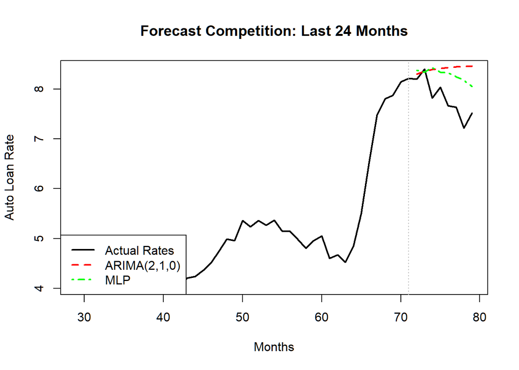

```r
## Plotting the Competition
time_axis = 1:n
zoom_start = n - 50

plot(time_axis[zoom_start:n], auto_rates[zoom_start:n], type="l", lwd=2,
     ylab="Auto Loan Rate", xlab="Months", main="Forecast Competition: Last 24 Months")

## Add the forecast lines for the test period
lines(time_axis[(n - test_size + 1):n], fore_arima$f, col="red", lwd=2, lty=2)
lines(time_axis[(n - test_size + 1):n], fore_mlp$mean, col="green", lwd=2, lty=4)

## Add a vertical line to show where the actual forecasts start
abline(v = n - test_size, col="gray", lty=3)

legend("bottomleft", legend=c("Actual Rates", "ARIMA(2,1,0)", "MLP"),
       col=c("black", "red", "green"), lty=c(1,2,4), lwd=2)
```

Of the two models we can see that the RMSE of the ARIMA(2,1,0) is the higher one at 0.721695 compared to the MLP Neural Network that has an RMSE of 0.5613905. Viewing the plot really puts into perspective how poor both models perform in actuality. However the plot also supports the statistical findings that the ARIMA performed worse. Although, I feel it only performed worse due to it it’s predictions following a more upward yet flat pattern where our MLP Neural Network’s predictions followed a downward slope. But as George Box said, “All models are bad but some are helpful! Meaning that even though both are incapable of catching the actual behavior of the loan rates they could potentially be helpful.

Due to this conclusion, I wanted to try creating an ensemble model as well as running rolling window RMSE’s to evaluate these models.

# Further Modeling (Ensemble)

**SHOW ME THE CODE!**

```r
cat("\n--- ENSEMBLE FORECAST ---\n")
```

```
--- ENSEMBLE FORECAST ---
```

**SHOW ME THE CODE!**

```r
## Average the two forecasts together
ensemble_pred = (fore_arima$f + fore_mlp$mean) / 2

## Calculate the Ensemble RMSE
rmse_ensemble = sqrt(mean((test - ensemble_pred)^2))
cat("Ensemble RMSE: ", rmse_ensemble, "\n")
```

```
Ensemble RMSE:  0.638926
```

**SHOW ME THE CODE!**

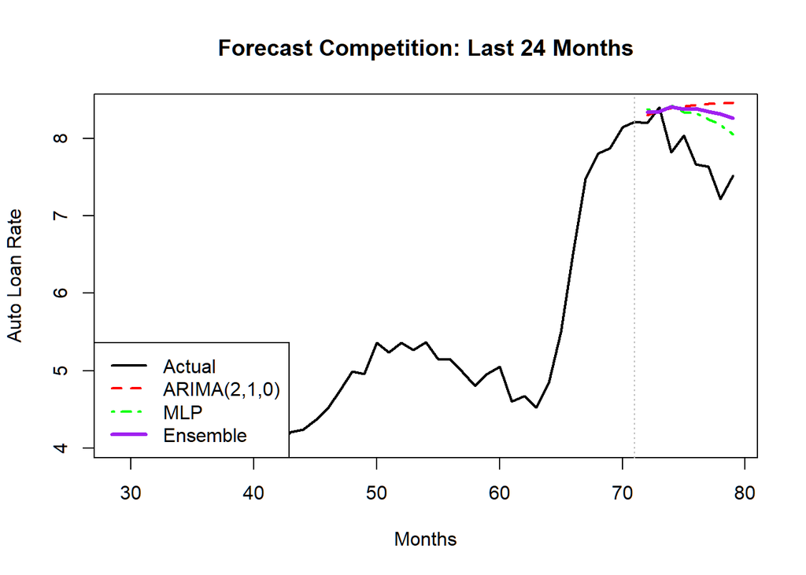

```r
## Plot the final 3-way competition
time_axis = 1:n
zoom_start = n - 50

plot(time_axis[zoom_start:n], auto_rates[zoom_start:n], type="l", lwd=2,
     ylab="Auto Loan Rate", xlab="Months", main="Forecast Competition: Last 24 Months")

## Add the individual forecast lines
lines(time_axis[(n - test_size + 1):n], fore_arima$f, col="red", lwd=2, lty=2)
lines(time_axis[(n - test_size + 1):n], fore_mlp$mean, col="green", lwd=2, lty=4)

## Add the new Ensemble forecast line
lines(time_axis[(n - test_size + 1):n], ensemble_pred, col="purple", lwd=3, lty=1)

abline(v = n - test_size, col="gray", lty=3)
legend("bottomleft", legend=c("Actual", "ARIMA(2,1,0)", "MLP", "Ensemble"),
       col=c("black", "red", "green", "purple"), lty=c(1,2,4,1), lwd=c(2,2,2,3))
```

While the Ensemble model performed better compared to the ARIMA, it displays how an ensemble CAN be useful if there are two distinctly opposing models (specifically distinctly opposing in this case). So while the ensemble is a superior model when compared to the ARIMA, the MLP Neural Network still wins out of these three.

Next I want to run rolling window RMSEs to see if either model (ARIMA or MLP) does better than our initial RMSEs.

# Rolling Window RMSEs

**ARIMA (2,1,0)**

**SHOW ME THE CODE!**

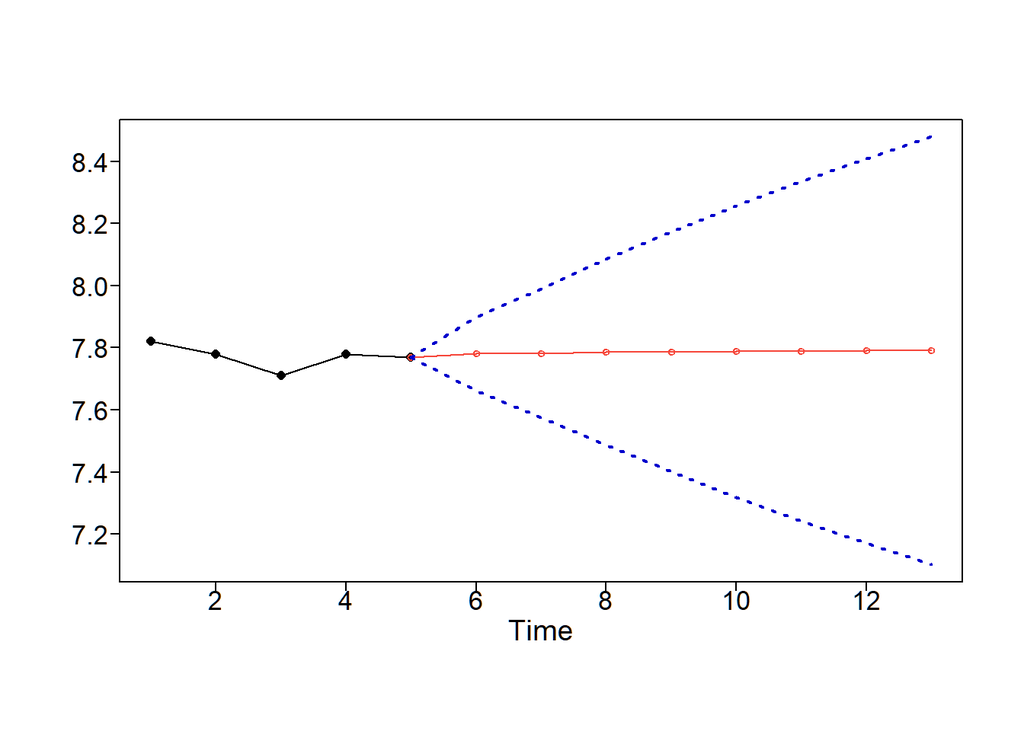

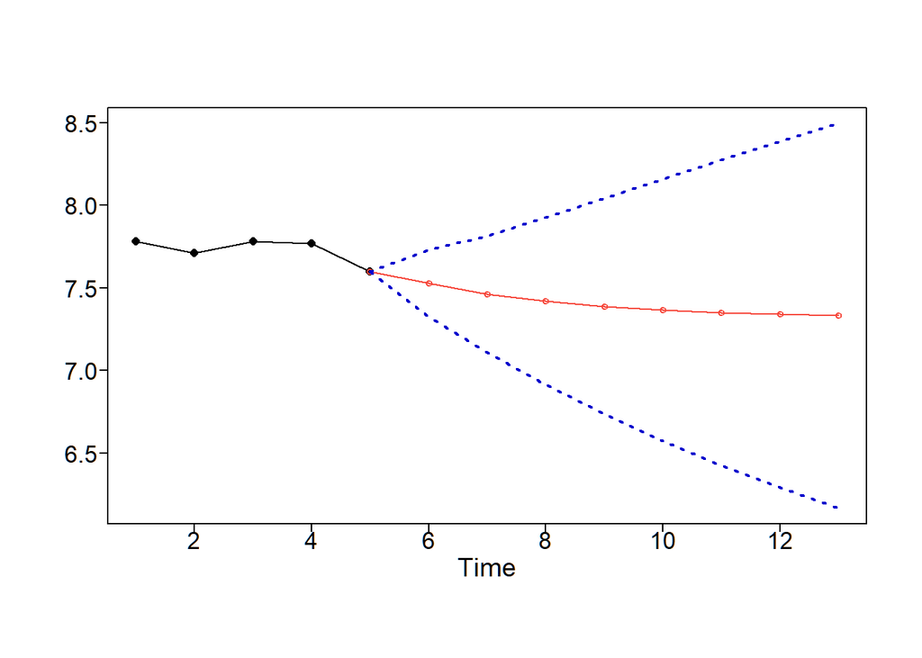

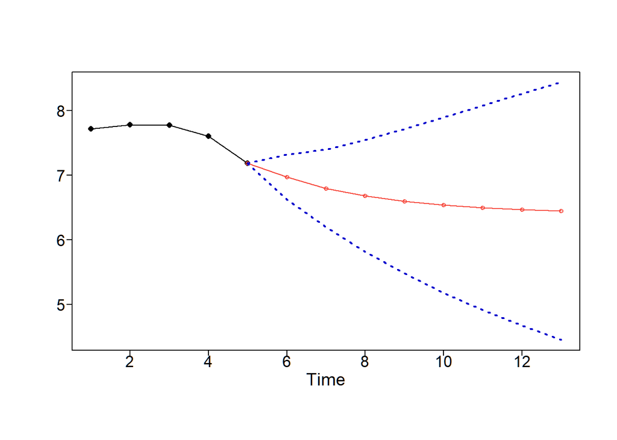

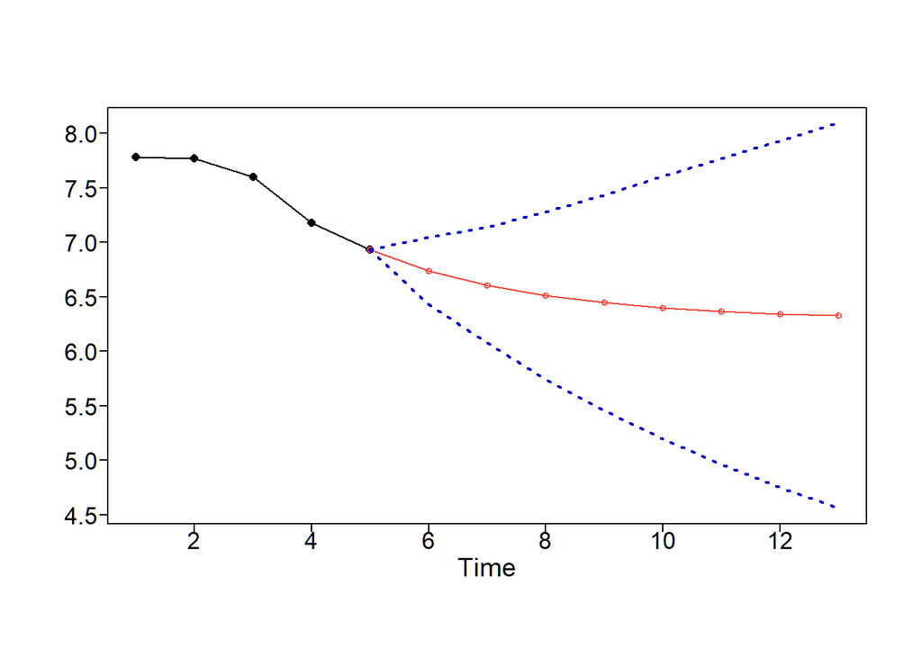

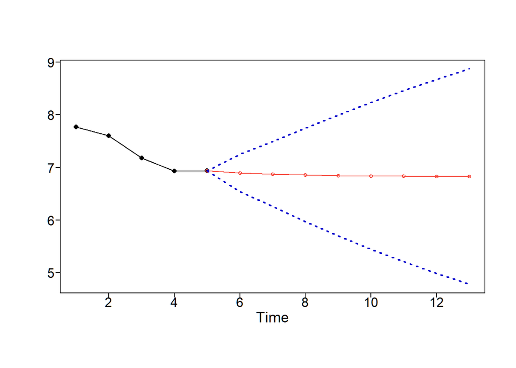

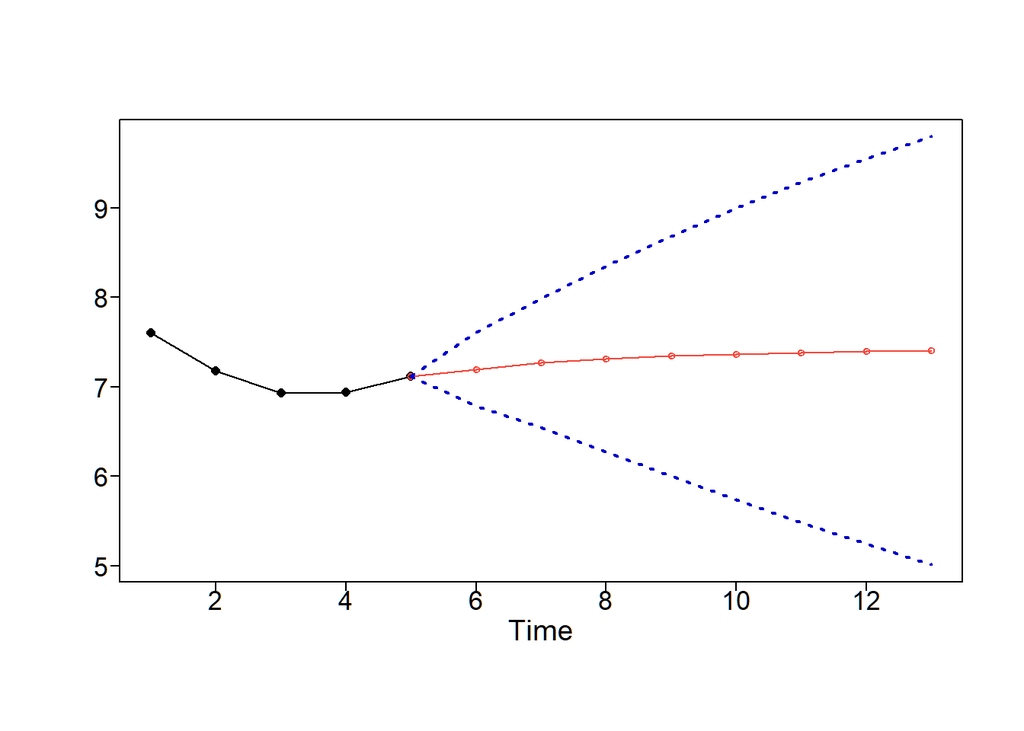

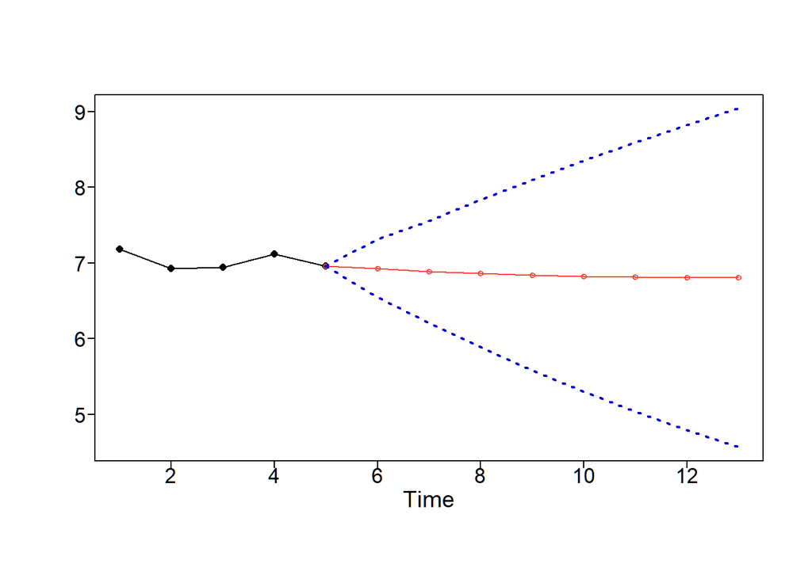

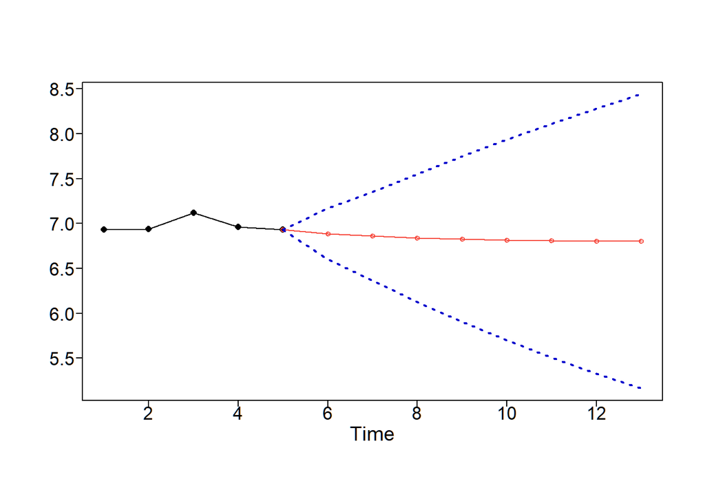

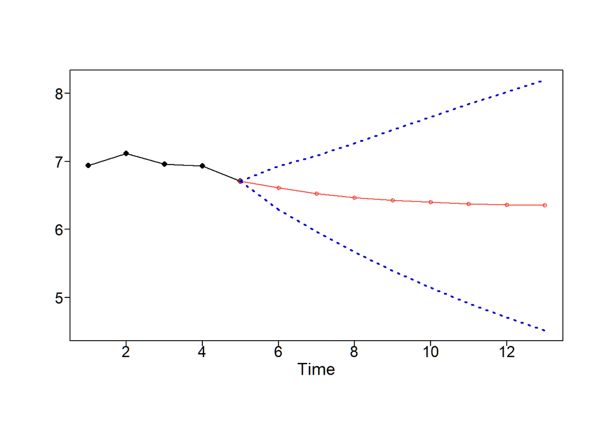

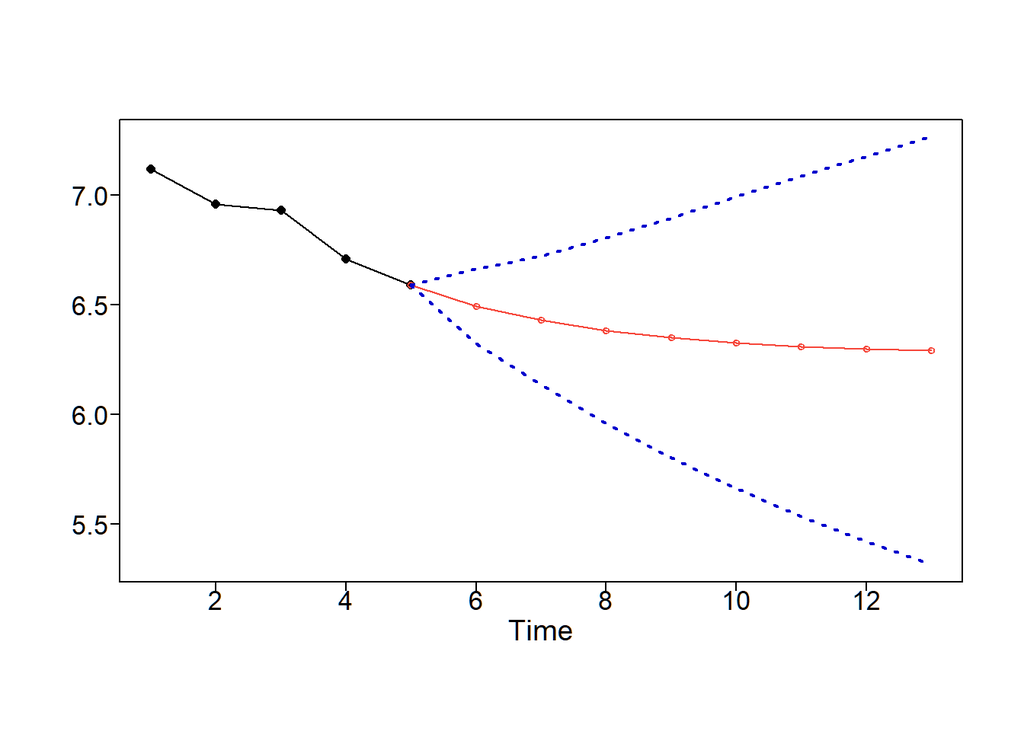

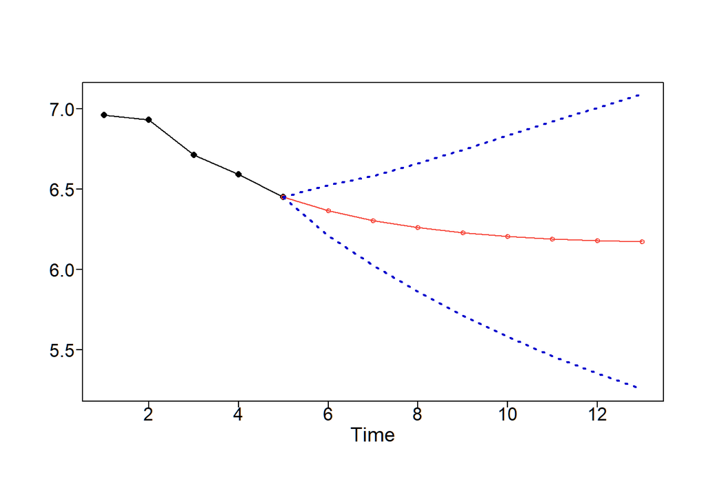

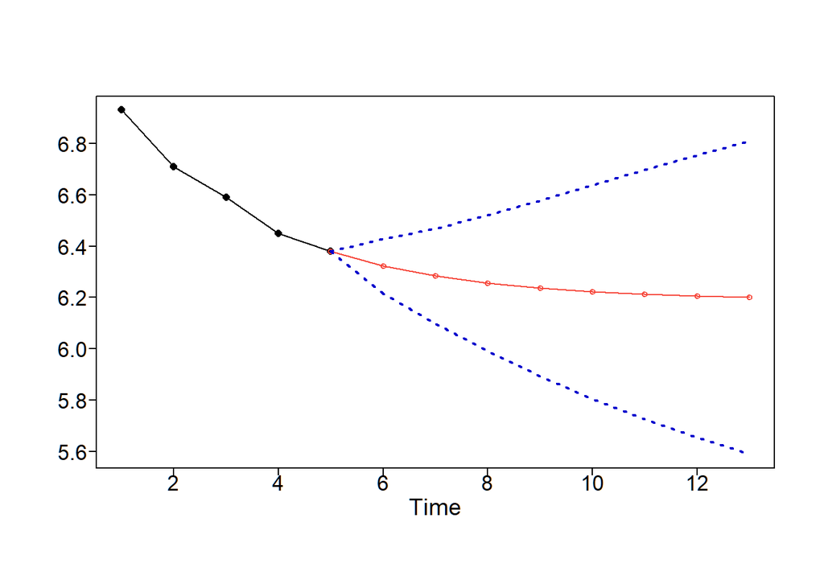

[56 more figures not shown]

```r
cat("\n--- ROLLING WINDOW RMSE ---\n")
## 1. ARIMA(2,1,0) Rolling Window
## We pass the full auto_rates dataset, d=1 for the unit root, and the fitted AR parameters
rw_arima = roll.win.rmse.wge(auto_rates, horizon = test_size, d = 1, phi = arima_fit$phi)
```

**SHOW ME THE CODE!**

```r
cat("ARIMA True Rolling RMSE: ", rw_arima$rwRMSE, "\n")
```

[output not shown]

**MLP Neural Network**

**SHOW ME THE CODE!**

[output not shown]

[output cut: 71 more lines]

[output not shown]

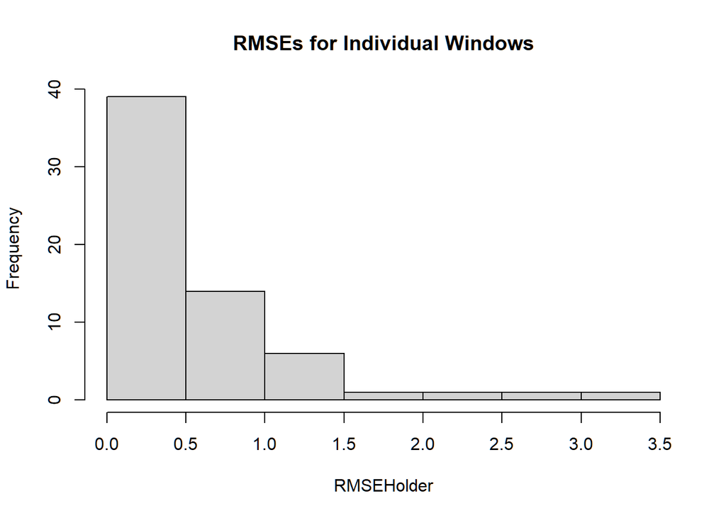

```r
## 2. MLP Rolling Window
## We set difforder=1 and allow.det.season=FALSE to match our previous MLP architecture
## NOTE: we set reps=5 so the computer is not overwhelmbed and does not freeze while rendering!
set.seed(1)
fit_mlp_fast = mlp(ts(auto_rates), difforder = 1, allow.det.season = FALSE, reps = 5)
rw_mlp = roll.win.rmse.nn.wge(auto_rates, horizon = test_size, fit_model = fit_mlp_fast)
```

**SHOW ME THE CODE!**

```r
cat("MLP True Rolling RMSE: ", rw_mlp$rwRMSE, "\n")
```

[output not shown]

### Table for report

**SHOW ME THE CODE!**

```r
library(tidyverse)
library(gt)

## Store the results in a small dataframe
rmse_results <- tibble(
  Model = c("ARIMA (2,1,0)", "MLP Neural Network"),
  Rolling_RMSE = c(rw_arima$rwRMSE, rw_mlp$rwRMSE)
)

## Build the table
rmse_results %>%
  gt() %>%
  ## titles
  tab_header(
    title = md("**Rolling Window RMSE Evaluation**"),
    subtitle = "Model Performance Comparison (Lower is Better)"
  ) %>%
  ## Format numbers to 4 decimal places
  fmt_number(
    columns = Rolling_RMSE,
    decimals = 4
  ) %>%
  ## Add a subtle color scale (highlights the winner)
  data_color(
    columns = Rolling_RMSE,
    palette = c("#a8ddb5","#e0f3db") ## Light, professional greens
  ) %>%
  ## Clean up the column labels
  cols_label(
    Model = md("**Predictive Model**"),
    Rolling_RMSE = md("**Rolling RMSE**")
  ) %>%
  ## Adjust alignment and width
  tab_options(
    table.width = pct(60),
    heading.align = "center",
    column_labels.background.color = "#f4f4f4"
  )
```

**Rolling Window RMSE Evaluation**

Model Performance Comparison (Lower is Better)

| **Predictive Model** | **Rolling RMSE** |
| --- | --- |
| ARIMA (2,1,0) | 0.6110 |
| MLP Neural Network | 0.5763 |

# Limitations and Future Considerations

Note that interest rates do not exist in a vacuum; they are heavily influenced by outside economic forces. By only looking at past loan rates, our current models are “blind” to the broader economy that could be helpful. In order to build better models we could collect more data on leading economic indicators such as the Federal Funds Rate, the US Unemployment Rate, or Total Vehicle Sales (Which is on FRED and we have used before in homework), and then use the Cross-Correlation Function to discover possible correlations between these datasets and if a spike in one leads to a spike or decrease in auto loan rates 2 quarters later! We could also create a VAR model with the aforementioned datasets to see if they are able to predict one another and adjust to sudden macroeconomic shocks that our simple ARIMA model could completely miss!

Overall, as this data, auto loan rates are very hard to predict as this data is somewhat similar to stocks which change DAILY any model will not be able to predict the next quarter or month very accurately. However, once again while our models are wrong/bad they can be helpful, instead we could potentially focus the models to simply predict if the loan rate with rise or fall and focus less on predicting the actual value of the loan rate.